# データ解析論I第9講

## 目次

## 前回の演習問題の回答

## 問題1

1. “ARE”についてヒストグラム（度数分布がわかるグラフ）を作成してください．

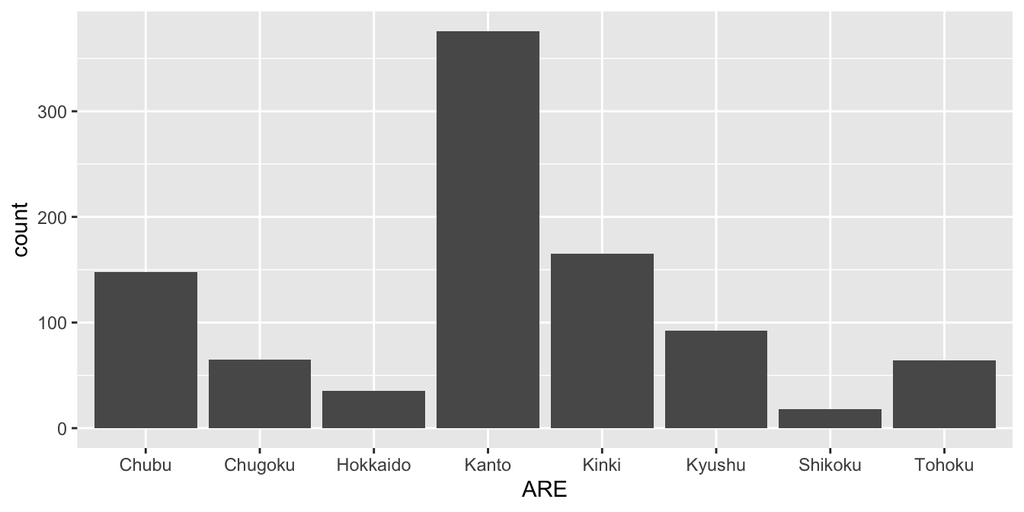

```r
exdataset%>%
  ggplot(aes(x=ARE),stat="count")+geom_bar()
```

```r
xtabs(~ ARE, exdataset)
```

```
## ARE
##    Chubu  Chugoku Hokkaido    Kanto    Kinki   Kyushu  Shikoku   Tohoku
##      148       65       35      376      165       92       18       64
```

1. “MAR”についてヒストグラム（度数分布がわかるグラフ）を作成してください．

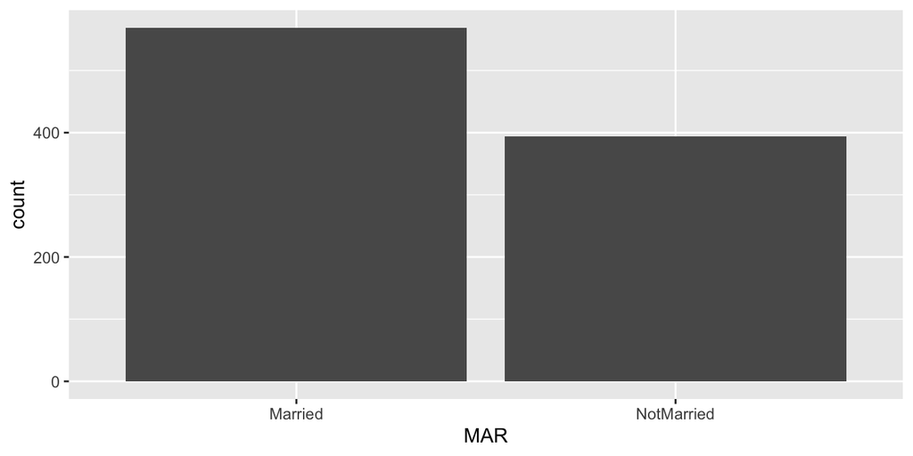

```r
exdataset%>%
  ggplot(aes(x=MAR),stat="count")+geom_bar()
```

```r
xtabs(~ MAR, exdataset)
```

```
## MAR
##    Married NotMarried
##        569        394
```

1. “ARE”と“MAR”についてクロス表を作成し，\(\chi^2\)検定を行ってください．

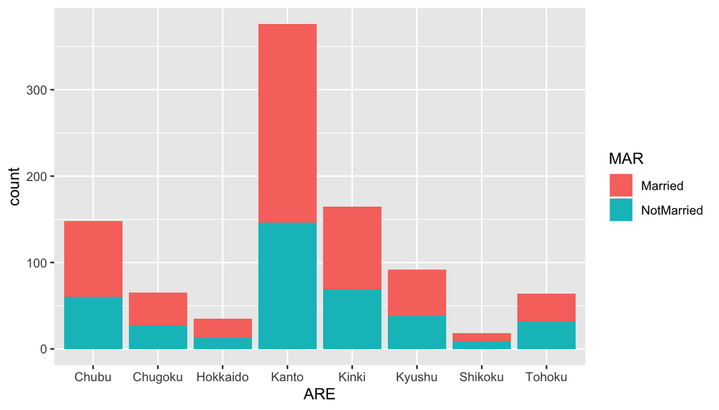

```r
exdataset%>%
  ggplot(aes(x=ARE, fill=MAR),stat="count")+geom_bar()
```

```r
xtabs(~ ARE + MAR, exdataset)
```

```
##           MAR
## ARE        Married NotMarried
##   Chubu         88         60
##   Chugoku       38         27
##   Hokkaido      22         13
##   Kanto        230        146
##   Kinki         96         69
##   Kyushu        54         38
##   Shikoku        9          9
##   Tohoku        32         32
```

```r
table<-xtabs(~ ARE + MAR, exdataset)
table
```

```
##           MAR
## ARE        Married NotMarried
##   Chubu         88         60
##   Chugoku       38         27
##   Hokkaido      22         13
##   Kanto        230        146
##   Kinki         96         69
##   Kyushu        54         38
##   Shikoku        9          9
##   Tohoku        32         32
```

```r
chitest.table<-chisq.test(table)
chitest.table
```

```
##
##  Pearson's Chi-squared test
##
## data:  table
## X-squared = 3.7625, df = 7, p-value = 0.8067
```

## 問題2

1. 睡眠満足度を応答変数，第二者被監視感“KAN_SEC”を説明変数とした回帰分析を行ってください．

```r
model1 <- lm(SUB_SLP ~ KAN_SEC, data=exdataset)
summary(model1)
```

```
##
## Call:
## lm(formula = SUB_SLP ~ KAN_SEC, data = exdataset)
##
## Residuals:
##     Min      1Q  Median      3Q     Max
## -6.3551 -2.0196 -0.0196  1.9804  4.6513
##
## Coefficients:
##             Estimate Std. Error t value Pr(>|t|)
## (Intercept)  6.69051    0.23697  28.234  < 2e-16 ***
## KAN_SEC     -0.33545    0.09794  -3.425 0.000641 ***
## ---
## Signif. codes:  0 '***' 0.001 '**' 0.01 '*' 0.05 '.' 0.1 ' ' 1
##
## Residual standard error: 2.501 on 961 degrees of freedom
## Multiple R-squared:  0.01206,    Adjusted R-squared:  0.01103
## F-statistic: 11.73 on 1 and 961 DF,  p-value: 0.0006411
```

1. 睡眠満足度を応答変数，第三者被監視感“KAN_THI”を説明変数とした回帰分析を行ってください．

```r
model1 <- lm(SUB_SLP ~ KAN_THI, data=exdataset)
summary(model1)
```

```
##
## Call:
## lm(formula = SUB_SLP ~ KAN_THI, data = exdataset)
##
## Residuals:
##     Min      1Q  Median      3Q     Max
## -6.3503 -1.9413  0.0587  2.0587  4.8766
##
## Coefficients:
##             Estimate Std. Error t value Pr(>|t|)
## (Intercept)  6.75928    0.21432  31.538  < 2e-16 ***
## KAN_THI     -0.40898    0.09767  -4.187 3.08e-05 ***
## ---
## Signif. codes:  0 '***' 0.001 '**' 0.01 '*' 0.05 '.' 0.1 ' ' 1
##
## Residual standard error: 2.494 on 961 degrees of freedom
## Multiple R-squared:  0.01792,    Adjusted R-squared:  0.0169
## F-statistic: 17.53 on 1 and 961 DF,  p-value: 3.081e-05
```

1. 睡眠満足度を応答変数，超自然的被監視感“KAN_SUP”を説明変数とした回帰分析を行ってください．

```r
model1 <- lm(SUB_SLP ~ KAN_SUP, data=exdataset)
summary(model1)
```

```
##
## Call:
## lm(formula = SUB_SLP ~ KAN_SUP, data = exdataset)
##
## Residuals:
##     Min      1Q  Median      3Q     Max
## -6.0625 -1.9481  0.0519  2.0519  4.2807
##
## Coefficients:
##             Estimate Std. Error t value Pr(>|t|)
## (Intercept)  6.17691    0.22002   28.07   <2e-16 ***
## KAN_SUP     -0.11440    0.09376   -1.22    0.223
## ---
## Signif. codes:  0 '***' 0.001 '**' 0.01 '*' 0.05 '.' 0.1 ' ' 1
##
## Residual standard error: 2.514 on 961 degrees of freedom
## Multiple R-squared:  0.001547,   Adjusted R-squared:  0.000508
## F-statistic: 1.489 on 1 and 961 DF,  p-value: 0.2227
```

## ダミー回帰分析とt検定

## ダミー回帰分析

t検定とは2群の「平均値」を比較する方法です．しかし，実はこれも一般線形モデルの枠組みの中で考えることが出来ます．ここではその考え方について説明します．そこには「ダミー変数」という考え方が必要になります．

## ダミー変数とは

一般線形モデルではこんなモデル式から考える，というような話をしたかと思います．

\[Y_i=\beta_1 X_1 + \alpha+\epsilon_i \]

- 回帰分析では\(Y_i\)と\(X_1\)が数値データだった場合を示していました．しかし，例えば\(X_1\)に入れたいのが未婚者か既婚者，という因子データだったとします．
- この場合は，未婚者に対して0，既婚者に対して1という数字を割り当てると次のように理解することができます．

### 0を割り振られた未婚者の場合

数式の\(X_1\)に0を代入しましょう．  
\[Y_i=\alpha+\epsilon_i \]

- 係数がなくなってしまいました．したがって，切片のみになります．

### 1を割り振られた既婚者の場合

数式の\(X_1\)に1を代入しましょう．  
\[Y_i=\beta_1 + \alpha+\epsilon_i \]

- \(X_1\)の係数のみが増えています．したがって，0を代入した未婚者に比べて，既婚者の方が\(\beta_1\)の分だけ変化していることがわかります．

このように，0か1の数字を入れてあげると0を入れられたグループと1を割り振られたグループでどれだけ差があるのか，ということを評価することができます．  
そして，その「差」がどの程度あるのかも比較することができます．ここでは，主観的幸福度に未婚者と既婚者の間に差があるのか否かを，先ほどと同じような流れで考えていきましょう．

## 仮説を立てる

t検定に当たるのは2つの群に差があるのか否か，です．「差がある」を対立仮説，「差があるとはいえない」を帰無仮説とします．したがって，以下のような仮説を立てることが出来ます．

- 対立仮説：未婚者と既婚者の主観的幸福度に差がある．
- 帰無仮説：未婚者と既婚者の主観的幸福度に差があるとはいえない．

## 平均値をプロットする

はじめに，分析対象となるデータを読み込んでおきましょう．

- 以前紹介した“esquisse”を使っていただいて構いません．動画をご確認ください．
- また，別の方法として`ggplotgui`を使ったプロットの方法についても紹介したいと思います．

```
library(ggplotgui)
ggplot_shiny(exdataset)
```

そうすると新しいウィンドウが開きます．

以下の通りの作業をしましょう．

- ggplotタブへ
- “*Type of graph:*”は“*Dot + Error*”，Y-variableは“*SUB_HAP*”，X-variableは“*MAR*”を設定
- “*Confidence Interval:*”を95%にする．
- R-codeタブへ行って，以下のコードのうち，真ん中のみを以下にする． -また，コード内の*df*を*dataset*に変える．

```r
# You need the following package(s):
library("ggplot2")

# The code below will generate the graph:
graph <- ggplot(exdataset, aes(x = MAR, y = SUB_HAP)) +
  geom_point(stat = 'summary', fun.y = 'mean') +
  geom_errorbar(stat = 'summary', fun.data = 'mean_se',
                width=0, fun.args = list(mult = 1.96)) +
  theme_bw()
```

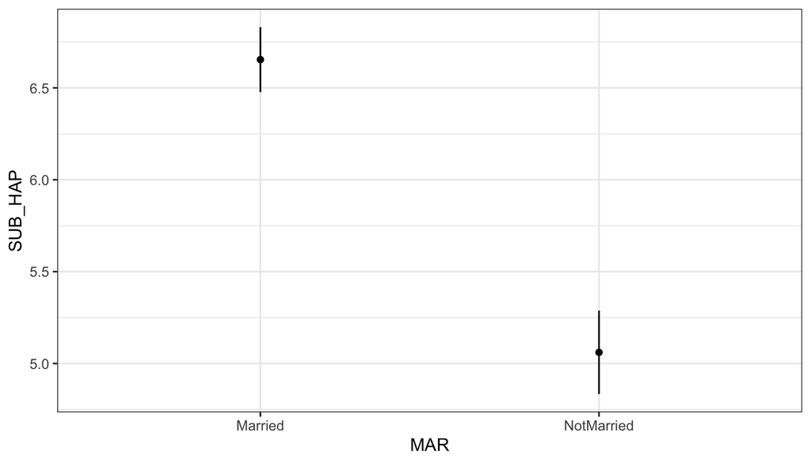

```r
graph
```

```r
# If you want the plot to be interactive,
# you need the following package(s):
library("plotly")
ggplotly(graph)
```

[interactive chart not shown]

これも同様に，本当に差があるのかどうかは，感覚的には明らかになっても科学的な根拠がありません．同じように検定をして確かめてみましょう．

## ダミー回帰をやってみる

```r
#"hapsat_model"というオブジェクトに，分析モデルを代入する．
marhap_model<-lm(SUB_HAP ~ MAR, data = exdataset)
```

```r
#分析結果の要約を出力する
summary(marhap_model)
```

```
##
## Call:
## lm(formula = SUB_HAP ~ MAR, data = exdataset)
##
## Residuals:
##     Min      1Q  Median      3Q     Max
## -6.6538 -1.6538  0.3462  1.3462  4.9391
##
## Coefficients:
##               Estimate Std. Error t value Pr(>|t|)
## (Intercept)    6.65378    0.09274   71.74   <2e-16 ***
## MARNotMarried -1.59286    0.14499  -10.99   <2e-16 ***
## ---
## Signif. codes:  0 '***' 0.001 '**' 0.01 '*' 0.05 '.' 0.1 ' ' 1
##
## Residual standard error: 2.212 on 961 degrees of freedom
## Multiple R-squared:  0.1116, Adjusted R-squared:  0.1106
## F-statistic: 120.7 on 1 and 961 DF,  p-value: < 2.2e-16
```

## 分析結果の見方

- さて，この分析結果の見方は基本的なところは回帰分析と一緒です．
- 特に着目すべきはCoefficientsのところなので，こちらについて説明します．

[output not shown]

\[Y_i=1.59291 X_1 + 5.0609+\epsilon_i \]

まずは係数について説明します．これは未婚者の場合と既婚者の場合について考えてみましょう．

## 未婚者の場合

未婚者の場合は\(X_1\)が0でした．したがって，以下のように示されます．

\[Y_i= 5.0609+\epsilon_i \]

- すなわち，未婚者の平均値の予測は5.0609であると推定されます．

## 既婚者の場合

既婚者の場合は\(X_1\)が1でした．したがって，以下のように示されます．

\[Y_i=1.59291 + 5.0609+\epsilon_i \]

- したがって，平均値は6.65381であると推定されます．
- また，これらの推定値の妥当性はp値によって推定されます．
- いずれの結果についても0.001%以下であるためにこの結果は統計的にも明らかな差があると理解できます．
- したがって，未婚者に比べて，既婚者の主観的幸福度は明らかに高いと理解することができます．この結果を簡単にまとめましょう．

## 結果をきれいに表記しよう．

- パッケージpanderの中にある関数panderを使うと，結果がわかりやすく表示されます．

```r
library(pander)
pander(marhap_model)
```

Fitting linear model: SUB_HAP ~ MAR

|  | Estimate | Std. Error | t value | Pr(>\|t\|) |
| --- | --- | --- | --- | --- |
| **(Intercept)** | 6.654 | 0.09274 | 71.74 | 0 |
| **MARNotMarried** | -1.593 | 0.145 | -10.99 | 1.571e-26 |

- 他にもパッケージhuxtableの中にhuxregという関数があります．

```r
library(huxtable)
huxreg(marhap_model)
```

|  | (1) |
| --- | --- |
| (Intercept) | 6.654 *** |
|  | (0.093) |
| MARNotMarried | -1.593 *** |
|  | (0.145) |
| N | 963 |
| R2 | 0.112 |
| logLik | -2130.084 |
| AIC | 4266.168 |
| *** p < 0.001; ** p < 0.01; * p < 0.05. |  |

- パッケージcoefplotを使って，各係数の大きさをグラフで示しておこう．
  - 特にこれから重回帰分析などを学ぶ上で知っておくと便利です．

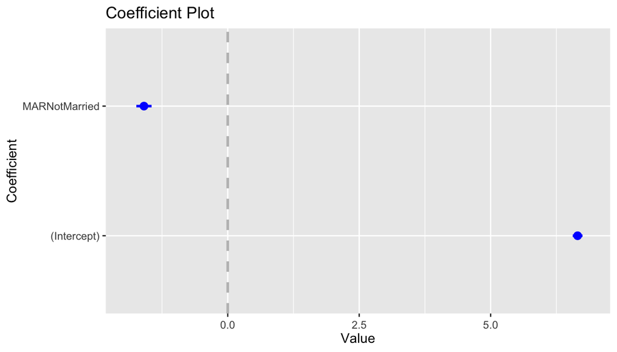

```r
# 初めて使う時はinstall.packages("coefplot")が必要です．
library(coefplot)
coefplot(marhap_model)
```

- パッケージstargazerの中にあるstargazerという関数を使うとxls形式で出力できます．

```
library(stargazer)
stargazer(marhap_model, type = "html", align=TRUE, title = "分析結果",
out = "marhap_model.xls")
```

- 作業フォルダの中に“marhap_model.xls”というファイルができていますので，そちらを開いてください．
  - 注意画面が出てきますが，「気にせずに開く」を選んでください．

## 結果の表記例．

- ダミー回帰分析モデルによって未婚者に比べて，既婚者の方が主観的幸福度が1.59高いこと0.001%水準で示された． （一緒に表を見せると良い．）
- ダミー回帰分析モデルによって未婚者に比べて，既婚者の方が主観的幸福度が1.59高いことが示された．（t(961)=10.99, p<.001）．
- \((主観的幸福度)=1.59291 (t=10.99) ×(既婚ダミー) \\+ 5.0609 + \epsilon_i\)

## t検定

## t検定

今までは一般線形モデルの枠組みからt検定の紹介を，すなわちダミー回帰分析の1つとしてのt検定を紹介しました．一方で，普通のt検定は以下のように行うことができます．

## ここだけの話．

- 最近はt検定にもいろいろな方法が提案されています．従来は等分散性を検定するF検定を実施し後に，等分散を仮定したスチューデント(Student)のt検定を行ったり，不等分散を仮定したウェルチ(Welch)のt検定を実施する，ということが行われてきました．
- しかしながら，2回検定を行うことは「検定の多重性」の観点から問題ではないか，という指摘もあったりします．
- そこで，最近ではF検定を実施せずに いきなりウェルチのt検定を行うことが多くなっています．

## ウェルチのt検定

```r
welch_t.testmodel<-t.test(SUB_HAP ~ MAR, data = exdataset)
welch_t.testmodel
```

```
##
##  Welch Two Sample t-test
##
## data:  SUB_HAP by MAR
## t = 10.854, df = 808.29, p-value < 2.2e-16
## alternative hypothesis: true difference in means is not equal to 0
## 95 percent confidence interval:
##  1.30479 1.88094
## sample estimates:
##    mean in group Married mean in group NotMarried
##                 6.653779                 5.060914
```

## 参考：スチューデントのt検定

```r
student_t.testmodel<-t.test(SUB_HAP ~ MAR, data = exdataset, var.equal = T)
student_t.testmodel
```

```
##
##  Two Sample t-test
##
## data:  SUB_HAP by MAR
## t = 10.986, df = 961, p-value < 2.2e-16
## alternative hypothesis: true difference in means is not equal to 0
## 95 percent confidence interval:
##  1.308323 1.877406
## sample estimates:
##    mean in group Married mean in group NotMarried
##                 6.653779                 5.060914
```

ちなみに，スチューデントのt検定と一般線形モデルにおけるダミー回帰モデルは結果が一致します．これは一般線形モデルが等分散性を仮定していることによります．

## 今日の要約

- ダミー回帰分析：
  - \[Y_i=\beta_1 X_1 + \alpha+\epsilon_i \]
  - をモデル式として，“\(Y_i\)”が数値データ，“\(X_1\)”が1or0の場合に用いる．
    - 対立仮説：“説明変数”の有無に応じて，“応答変数”が影響を受ける
    - 帰無仮説：“説明変数”の有無に応じて，“応答変数”が影響を受けるとは言えない．
  - Rの関数では次の形式を用いる．

```
# モデルを作る
オブジェクト <- lm(応答変数 ~ 説明変数, data = データセットの名前)

# 結果を出力する
summary(オブジェクト)
```

## 今日の要約

- t検定
  - 平均値の差の検定としてのt検定は以下のように検定する．

```
オブジェクト <- t.test(応答変数(数量データ) ~ 説明変数(2つで分けられるもの),
                                              data = データセットの名前)
オブジェクト
```

## jamoviでの実行方法

## jamoviでの実行方法

- ダミー回帰分析
  - グラフ作成
  - 分析
- t検定
  - グラフ作成
  - 分析

## 演習問題

## 演習問題

```
"CHI"は子どもの有無を尋ねる項目である．
あなたはお子さんがいらっしゃいますか？
これについて，以下の3つの分析を実施せよ．また，それぞれについてグラフも作成せよ．

    * 子の有無による主観的幸福度の差を分析せよ．
    * 子の有無による生活満足度の差を分析せよ．
    * 子の有無による睡眠満足度の差を分析せよ．
```